# Fenestrations and branches

Martin Hennessy

28/04/2023

# 1 Timeline of data

The data presented here are from fenestrated or branched EVAR performed between 17 December 2009 and 24 April 2023 and comprise 83 cases.

Both urgent and elective cases are included.

# 2 Fenestrations and branches - counts

## 2.1 Number of each

In general, fenestrations are preferred to branches but urgent cases are almost exclusively treatable only with branches.

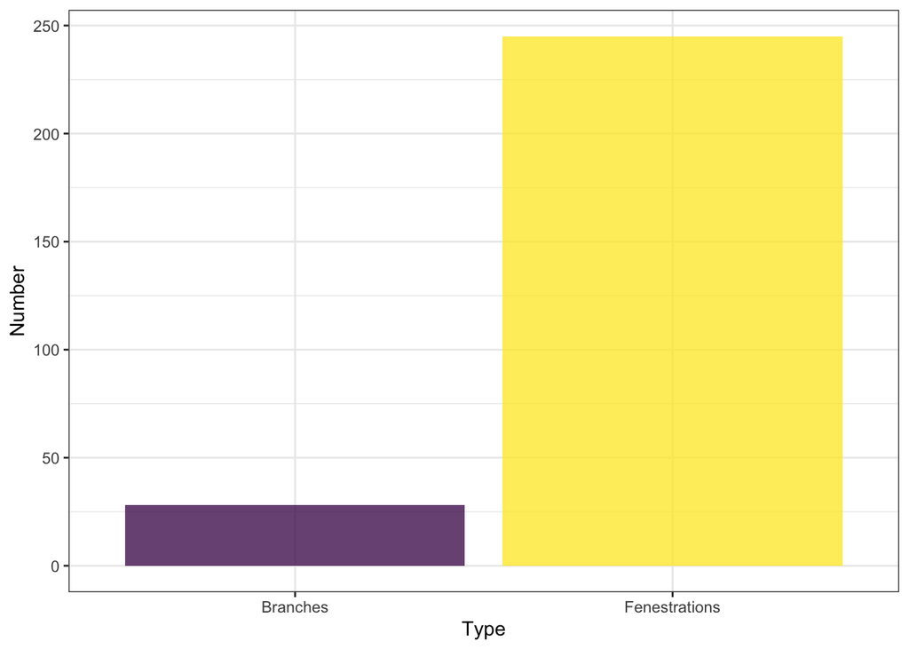

## 2.2 Vessels stented

Stenting all four vessels is the most common scenario.

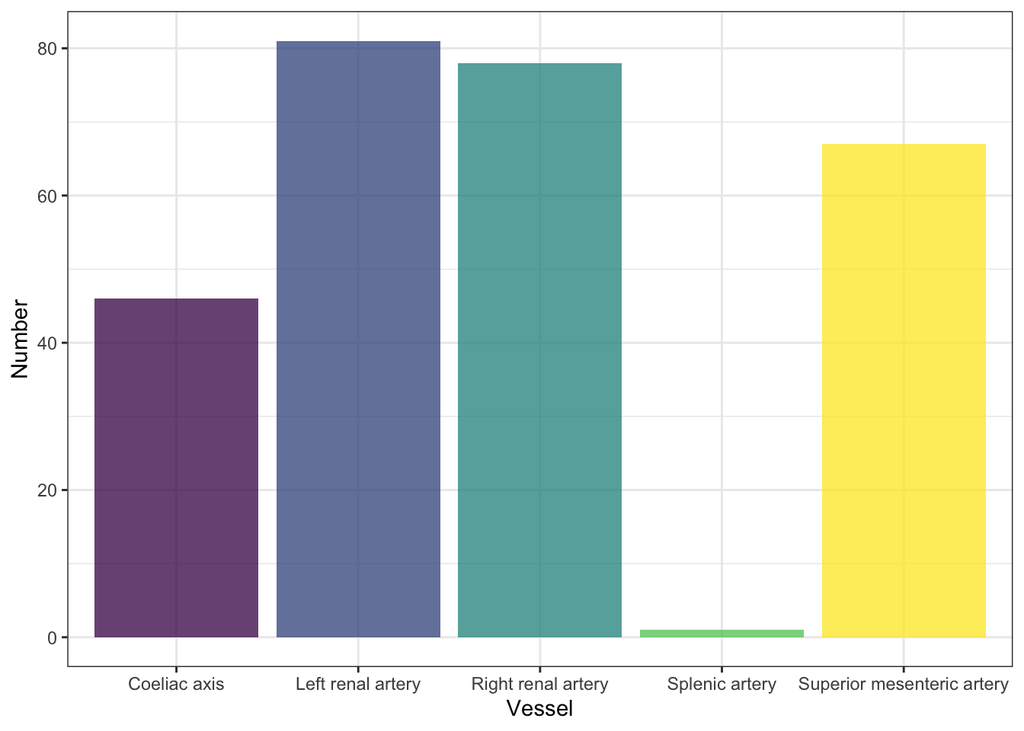

## 2.3 Stent-grafts used

Largely for availability reasons, choice of stent-graft moved to VBX when Atrium (V12 Advanta) became more unreliable to source.

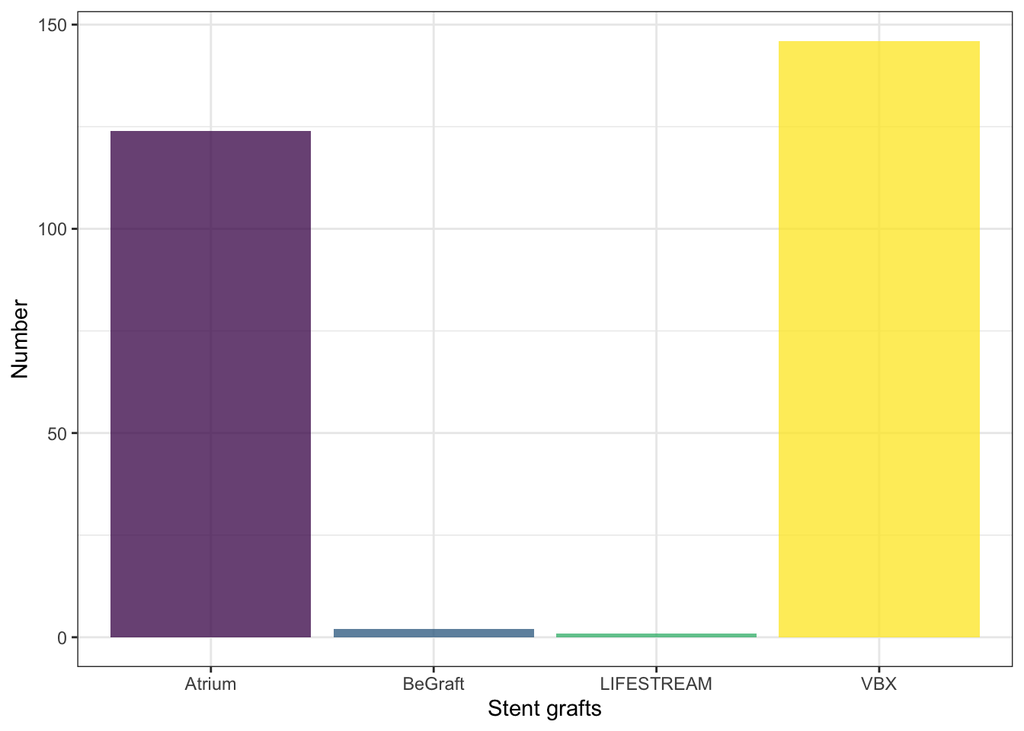

# 3 Fenestrations and branches - sizes

## 3.1 Size of stent-grafts

- Size of some stent-grafts could not be obtained (n = 7)
- Splenic artery was stented once; this is not included
- CA = coeliac axis, LRA & RRA = left and right renal arteries, SMA = superior mesenteric artery
- In some situations, a larger stent (eg. 7 mm VBX) is deliberately under-inflated in a smaller vessel as the 7 mm VBX will flare more reliably and easily than the 6 mm device

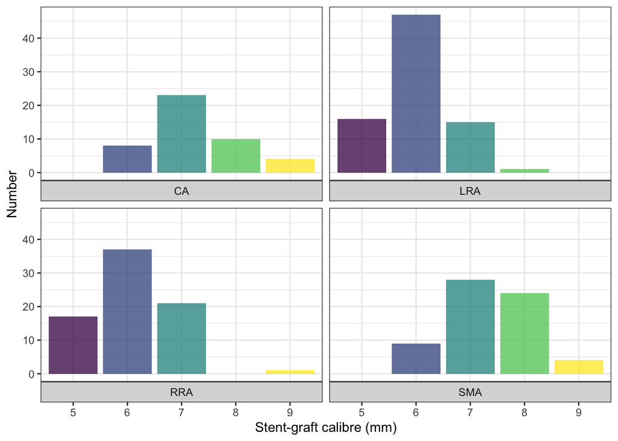

# 4 Fenestration and branch occlusion

**These all reflect imaging-proven stent-graft occlusion.**

## 4.1 Occlusion in fenestrations and branches

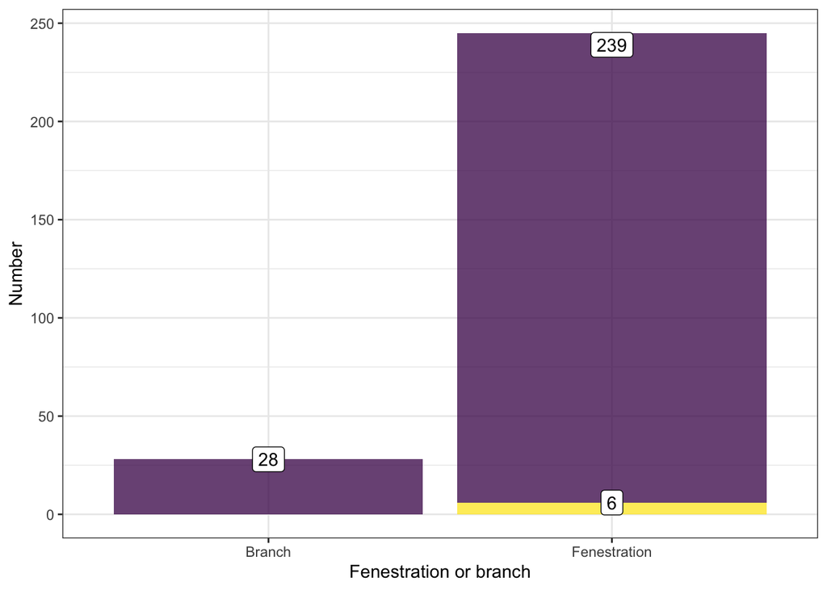

- Overall fenestration occlusion rate = 2%

## 4.2 Occlusion depending on aortic device

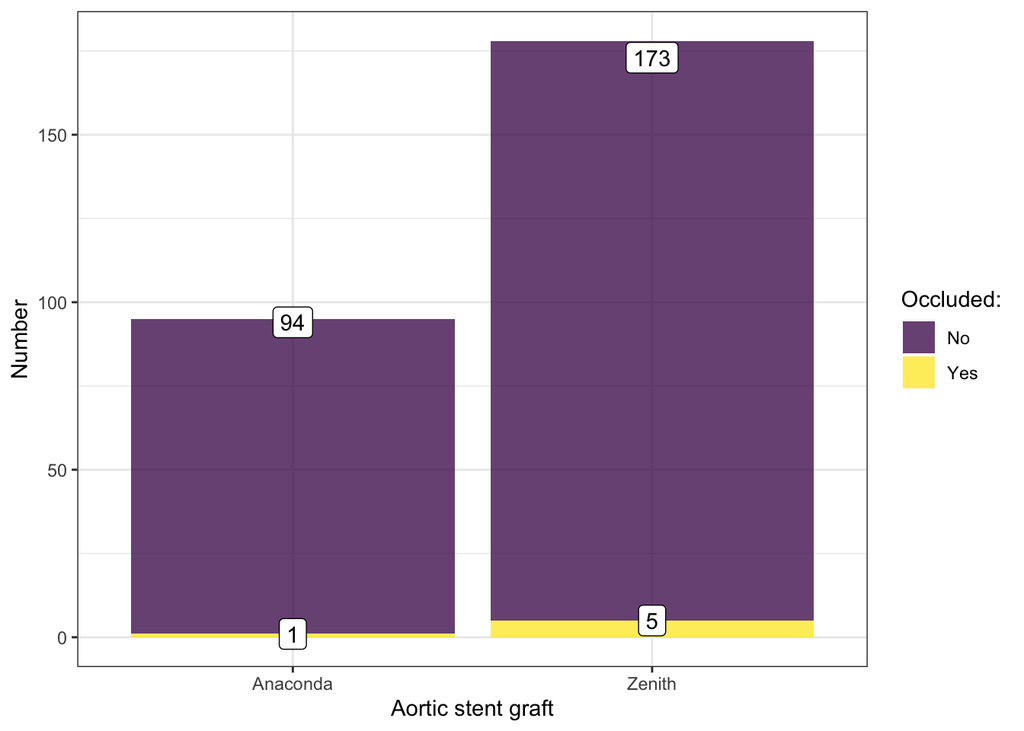

## 4.3 Occlusion in vessels

- Splenic artery is again omitted as it was only stented once
- Of note, the case in which both coeliac axis and splenic artery were individually stented resulted in coeliac axis fenestration occlusion and splenic fenestration patency

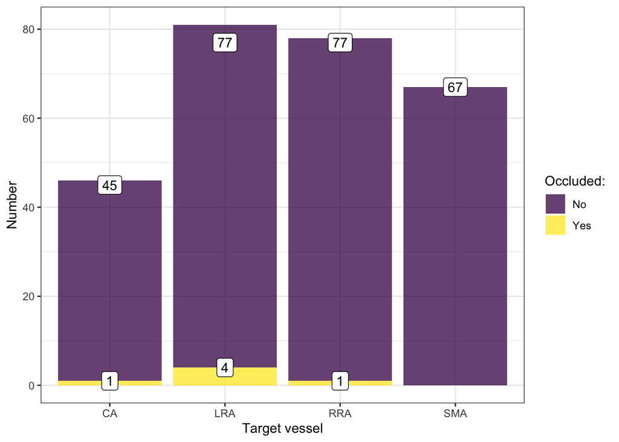

## 4.4 Occlusion by stent-graft

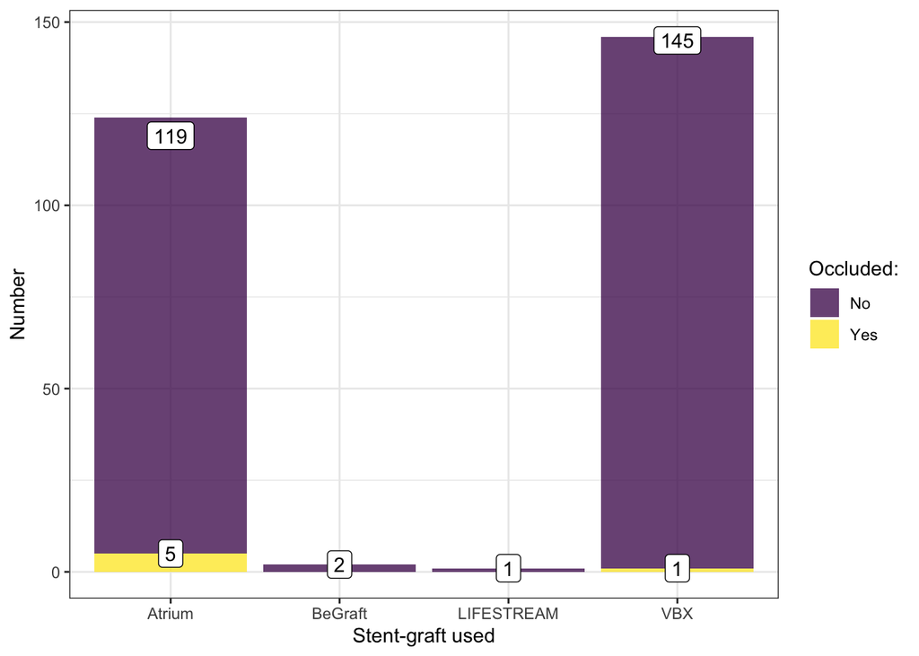

## 4.5 Occlusion by stent-graft calibre

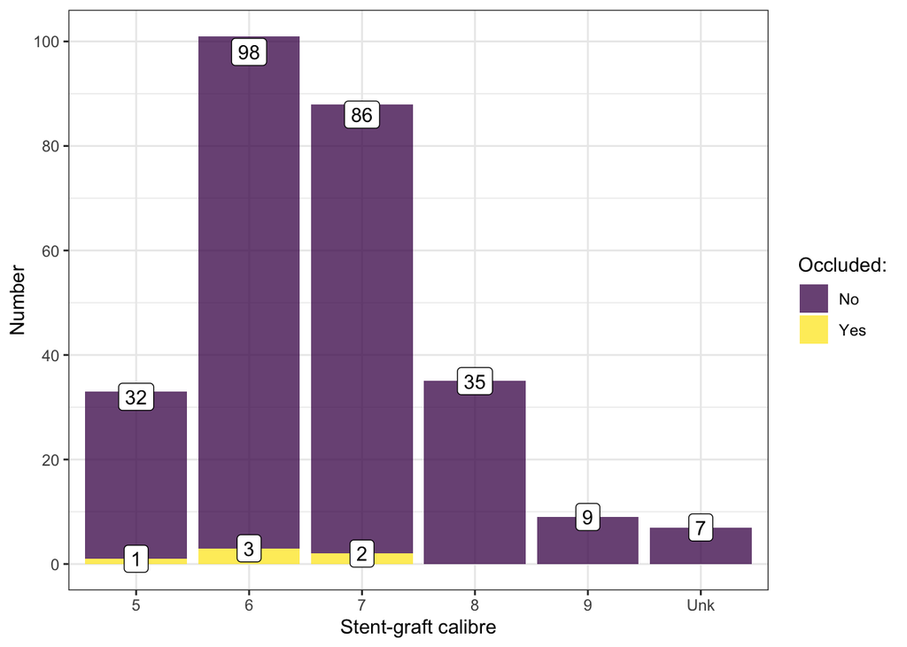

# 5 Occlusion expressed as survival

**Please note the y-axes in the following KM curves**

## 5.1 Overall occlusion survival

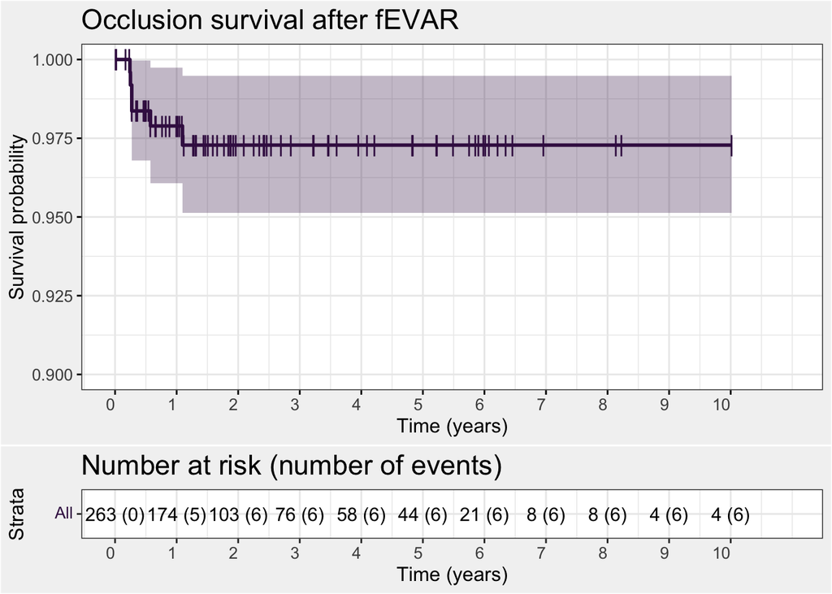

## 5.2 Survival in fenestrations and branches

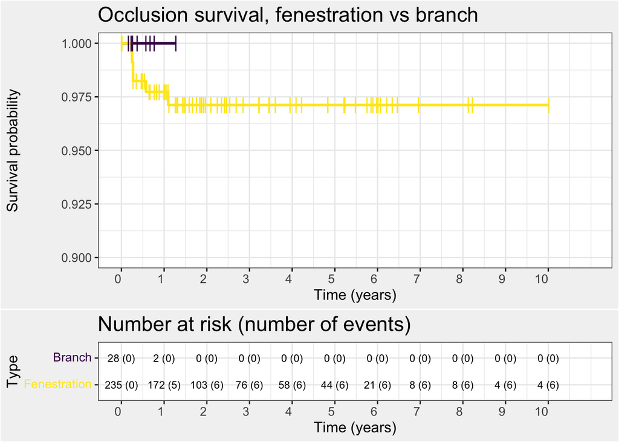

## 5.3 Survival in vessels

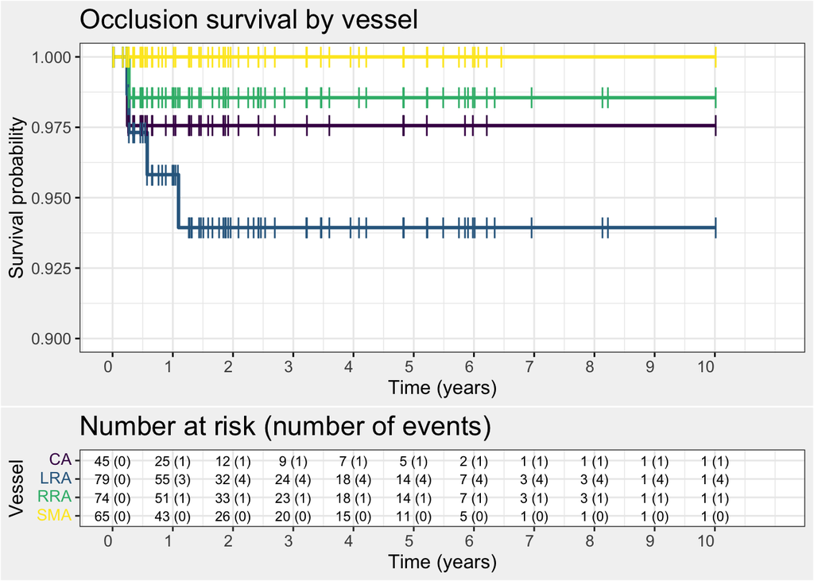

## 5.4 Survival Atrium vs VBX

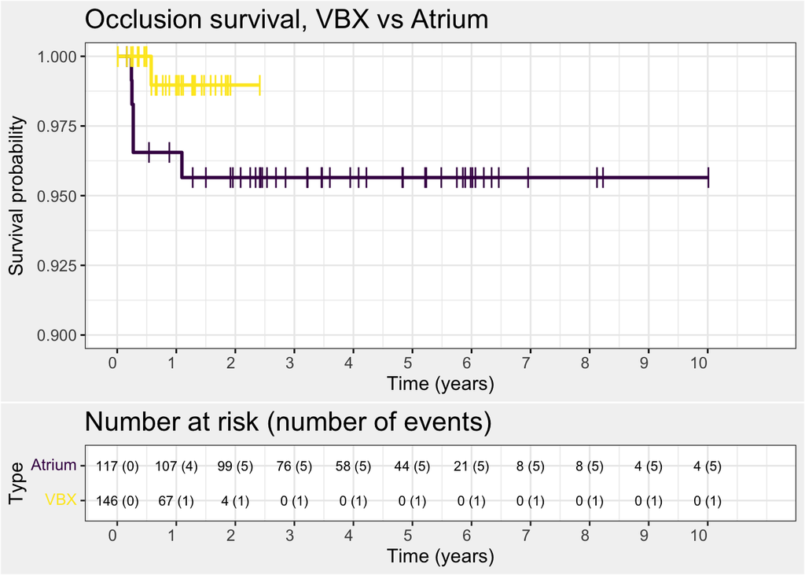

## 5.5 Survival by stent-graft calibre

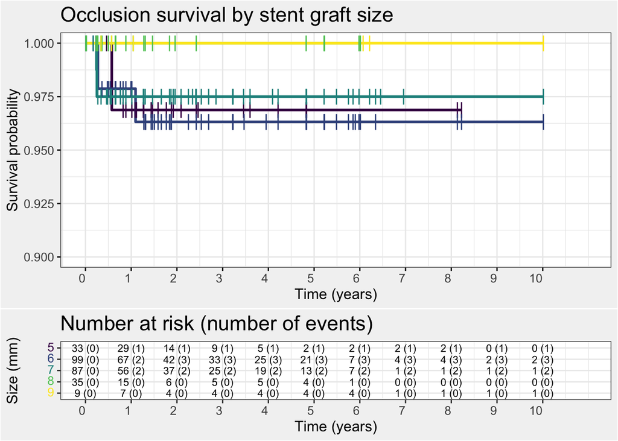